# HemoAtlas Database

# 1. HemoAtlas数据库概述

## 1.1 血友病A专病多组学数据库

- Genetic Information
- Clinical Presentations
- Transcriptomic Data
- Protein Information
- Drug Discovery
- Support

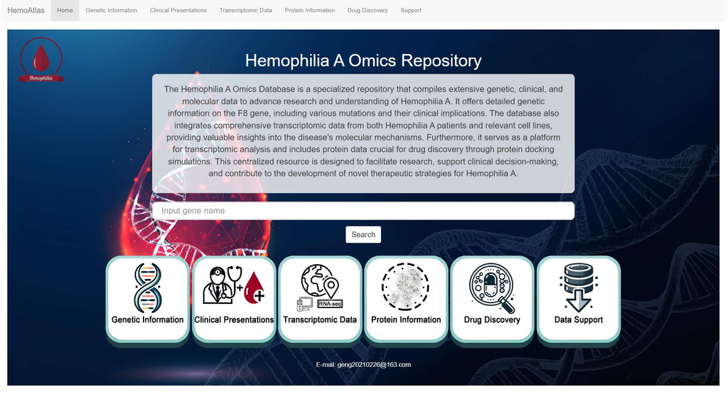

### F8基因突变信息模块

该模块详细记录了血友病A患者中F8基因的突变信息，包括基因突变对患者疾病严重程度的影响。通过分析基因型与表型之间的关系，研究人员可以更好地理解疾病的遗传基础，并为患者提供个性化的治疗方案。据最新数据，该模块已经收录了超过**1000**个**F8**基因突变案例，涵盖了从轻型到重型的全谱系病例。同时我们在页面的左侧以饼图的形式详细的展示，不同突变类型占比，及患者严重程度分布情况。

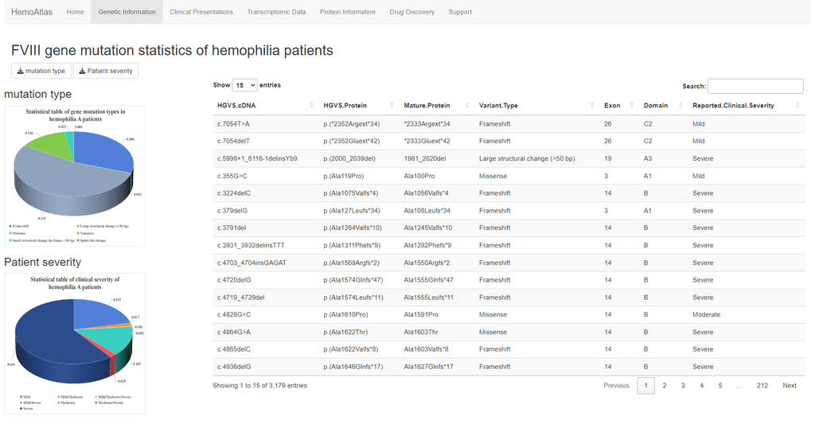

### 血友病A临床信息模块

此模块收集了血友病A患者的临床信息，包括相关疾病和临床表征。这些数据有助于医生在诊断和治疗过程中做出更准确的决策。目前，该模块已经整合了来自多个医疗机构的临床数据，覆盖了全球范围内的血友病A患者群体。

同时我们使用互作网络为用户提供了可视化的动态交互网络。

[figure not shown]

### 转录组测序数据及生物信息学分析工具模块

HemoAtlas提供了血友病患者和F8-KO细胞系的转录组测序数据，以及一系列生物信息学分析工具。这些工具可以帮助研究人员深入分析基因表达模式，识别疾病相关的生物标志物，从而为新疗法的开发提供理论基础。

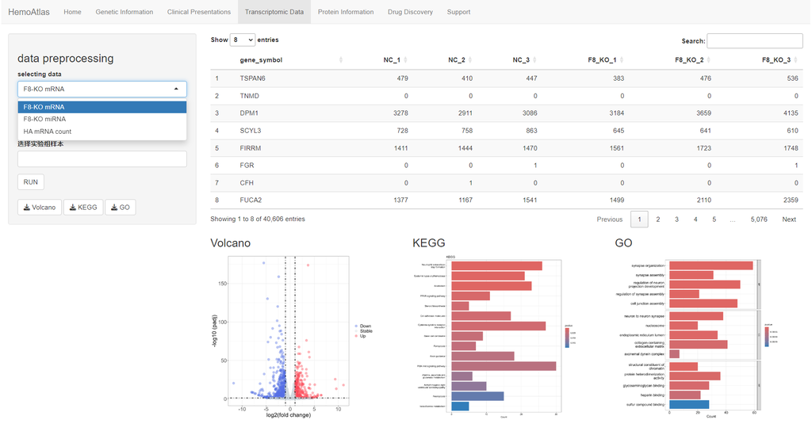

具体操作流程如下：

- 在“data preprocessing”处选择测序数据集（F8-KO mRNA、F8-KO miRNA、HA mRNA），这些数据均支持使用DEseq2包进行差异表达分析。
- 按照数据集要求选择分组（对照组、实验组）。随后点击“RUN”，等待计算完成！
- 计算完成后，右侧的表达矩阵将被替换成为差异表达基因列表，用户可以通过检索排序筛选基因。
- 同时页面将为用户提供差异表达基因火山图、基因通路富集图谱（KEGG、GO），并支持用户下载至本地。

### F8蛋白质结构和药物结构信息模块

这些数据支持用户下载至本地，这对于研究基因突变对F8蛋白质结构的影响，以及基于结构的药物设计研究至关重要。

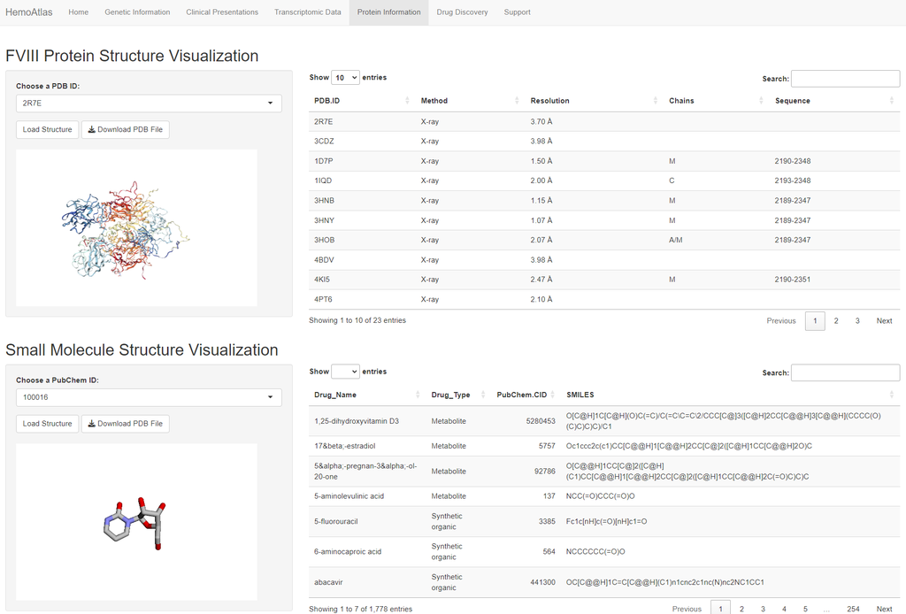

### 血友病A药物信息模块

此模块提供了血友病A目前公开使用的药物信息，包括药物的名称、研究状态（是否被批准）、相关数据库信息等。这些信息对于医生在临床实践中选择合适的药物治疗方案至关重要。数据库中的药物信息定期更新，以反映最新的临床指南和研究进展。

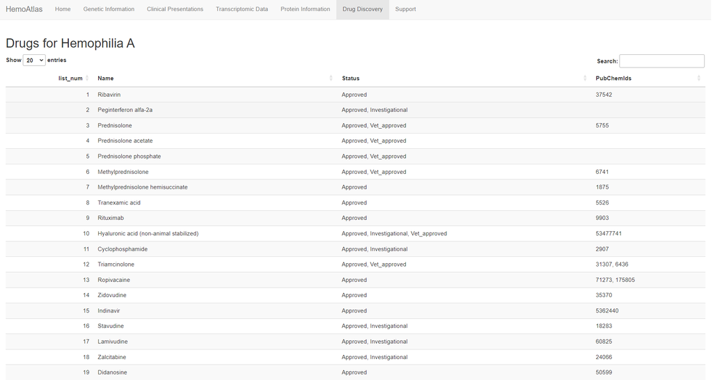

总体而言，HemoAtlas数据库通过整合多组学数据，为血友病A的研究和临床实践提供了一个强大的数据支持平台。随着数据库的不断更新和扩展，它将在推动血友病A的科学研究和改善患者治疗结果方面发挥越来越重要的作用。

# 2. 数据库功能与应用

## 2.1 预防支持

HemoAtlas数据库在血友病A的预防方面提供了重要的数据支持。通过F8基因突变信息模块，研究人员能够识别和分析与血友病A相关的基因变异，这些信息对于开展遗传咨询和家族筛查至关重要。例如，通过分析F8基因突变对疾病严重程度的影响，可以预测携带特定突变的个体发病的风险，从而为高风险家庭提供预防指导和干预措施。

此外，血友病A临床信息模块收集的临床表征数据，有助于医生了解疾病的自然病史和潜在的触发因素，从而为患者提供生活方式的调整建议，以降低发病风险。例如，通过分析出血事件与特定活动或环境因素的关联，可以为患者制定个性化的预防出血方案。

## 2.2 诊断辅助

在诊断方面，HemoAtlas数据库提供了丰富的信息资源，辅助医生进行更准确的诊断。F8基因突变信息模块通过提供详尽的基因突变数据，帮助医生识别患者是否携带已知的血友病A相关突变，从而快速确诊。此外，该模块中包含的基因型与表型关系数据，可以辅助医生判断患者疾病的严重程度，为后续治疗提供指导。

血友病A临床信息模块中的临床表征数据，为医生提供了疾病的典型和非典型症状信息，有助于在早期识别血友病A，尤其是在症状不典型或轻微的情况下。转录组测序数据及生物信息学分析工具模块提供的基因表达模式和生物标志物信息，可以作为诊断的辅助手段，提高诊断的准确性。

## 2.3 治疗数据支撑

HemoAtlas数据库在治疗方面提供了强有力的数据支撑。F8蛋白质结构和药物结构信息模块提供了F8蛋白质及其突变体的三维结构，这对于理解蛋白质功能和药物作用机制至关重要。这些结构信息可以帮助研究人员设计更有效的治疗方案，如蛋白质替代疗法或基因治疗。

此外，转录组测序数据及生物信息学分析工具模块提供的生物标志物信息，可以用于监测治疗效果和预测患者对特定治疗的反应，从而实现精准医疗。通过这些数据，研究人员和医生可以更好地理解治疗效果的分子机制，为患者提供更有效的治疗选择。

# 4. 总结

HemoAtlas数据库作为一个专注于血友病A的专病多组学数据库，集成了F8基因突变信息、临床数据、转录组测序数据、蛋白质与药物结构信息以及药物信息等多个模块，为血友病A的预防、诊断和治疗提供了全面的数据分析和支持。

## 4.1 数据库的综合优势

HemoAtlas的综合优势在于其多维度的数据整合能力。通过将基因突变数据与临床表征相结合，数据库能够为研究人员提供从分子层面到临床实践的全面视角。这种整合不仅有助于揭示疾病的复杂机制，还能够促进个性化医疗的发展。例如，通过分析F8基因突变与临床症状的关联，可以为患者提供更为精确的治疗方案。

## 4.2 对科研和临床实践的贡献

HemoAtlas数据库对科研和临床实践的贡献显著。在科研领域，转录组测序数据和生物信息学分析工具的应用已经支持了众多科学论文的发表，推动了血友病A相关研究的进展。在临床实践中，数据库提供的F8蛋白质结构、药物信息以及药物反应的生物标志物数据，为医生制定治疗方案提供了重要依据。

## 4.3 未来发展方向

展望未来，HemoAtlas数据库将继续扩展其数据内容，增加更多样本和更详细的突变信息，以提高数据库的覆盖面和深度。同时，数据库也将引入更多的生物信息学分析工具，以支持更复杂的数据分析需求。此外，随着精准医疗的发展，HemoAtlas数据库有望在个性化治疗方案的制定中发挥更大的作用，为血友病A患者提供更优质的医疗服务。